# Esercizi

Ottavia M. Epifania

# 1 Baby steps

## 1.1 Calculato**R**

Write the following operations (results are in square brackets):

1. $\sqrt{(15)} * 14 - \frac{22}{4}$ [48.72177]

**See solution**

```r
sqrt(15) *14 - 22/4
```

```
## [1] 48.72177
```

2. $\frac{\sqrt{7-\pi}}{3\ (45-34)}$ [0.05952372]

**See solution**

```r
sqrt(7 - pi)/(3*(45 -34))
```

```
## [1] 0.05952372
```

3. $\frac{e^{(5-4)}}{1+e^{(5-4)}}$ [0.7310586]

**See solution**

```r
exp(5-4)/(1+exp(5-4))
```

```
## [1] 0.7310586
```

4. $log(\frac{0.7}{1-0.5})* \sqrt{(\frac{20\times 3}{2})^5}$ [1658.641]

**See solution**

```r
log(0.7/(1-0.5)) * sqrt(((20 *3)/2)^5)
```

```
## [1] 1658.641
```

5. $\frac{\sum_{n=1}^{10} n}{10}$ [5.5]

**See solution**

```r
sum(1:10)/10
```

```
## [1] 5.5
```

Details:

- Square root: `sqrt()`
- $e$: `exp(1)`.
- $log$: `log(x, base=a)`
- $\pi$: `pi`

## 1.2 Vectors

1. Create a vector `x` of length 7 containing only odd numbers

**See solution**

```r
x = seq(1, 13, by=2)
```

2. Create a vector `y` from `x` such that it includes the values $\leq 3$ and those $\geq 9$:

**See solution**

```r
y = x[x <= 3|x >=9]
```

3. Create vector `z` from `y` such that it includes the values $<$ $M(y)$:

**See solution**

```r
z = y[y < mean(y)]
```

4. Create this vector: on, on, on, on, on, off, off and name it `v`:

**See solution**

```r
v = rep(c("on", "off"), c(5, 2))
```

5. Create this vector A1, A2, B1, B2, C1, C2, D 1, D 2, A, B and name it `h`:

**See solution**

```r
h = c(paste0("A", 1:2), paste0("B", 1:2), paste0("C", 1:2),
      paste0("D", 1:2), LETTERS[1:2])
```

6. From vector `h`, select only the elements containing number 1 and store them in vector `g`:

**See solution**

```r
g = h[grepl("[1]", h)]
g
```

```
## [1] "A1" "B1" "C1" "D1"
```

7. Replace all elements in `h` that contains A or B and a number with “!”:

**See solution**

```r
gsub("[AB]+[0-9]", "!", h)
```

```
##  [1] "!"  "!"  "!"  "!"  "C1" "C2" "D1" "D2" "A"  "B"
```

## 1.3 Data frames

`light` and `group` are crossed factors in a balanced design, so there are 10 subjects in each cell. Check the structure of the data set (hint: use `tab()`)

**See solution**

```r
dat = data.frame(id = paste0("sbj", 1:60),
                 light = factor(rep(c("low", "medium", "high"), each=10),
                              levels = c("high", "medium", "low")),
                 group = factor(rep(c("control", "treatment"), each=30),
                 levels = c("treatment", "control")))
# check
table(dat$light, dat$group)
```

```
##
##          treatment control
##   high          10      10
##   medium        10      10
##   low           10      10
```

2. Add column `growth` to `dat` with response times drawn from a gamma distribution (use `set.seed(999)`, and set `shape = 1` in the function for generating the data)

**See solution**

```r
set.seed(999)
dat$growth = rgamma(60, shape=1)
```

3. Order the data frame by decreasing `growth`:

**See solution**

```r
dat = dat[order(dat$growth, decreasing = T), ]
```

4. Compute the mean and standard deviation of `growth` considering `light * group`. Save the results in two objects (`mean_growth` and `sd_growth`)

**See solution**

```r
mean_growth = aggregate(growth ~ light * group, data = dat, mean)
sd_growth = aggregate(growth ~ light * group, data = dat, sd)
```

5. Rename the last column of `mean_growth` and `sd_growth` in `m_growth` and `sd_growth`, respectively, **without using manual indexing** (e.g., `colnames(mean_growth)[3]`)>

**See solution**

```r
# indexing the position
colnames(mean_growth)[ncol(mean_growth)] = "m_growth"

# explicitly referring to the name of the column
names(sd_growth)[colnames(sd_growth) == "growth"] ="sd_growth"
```

6. Merge `mean_growth` and `sd_growth` in `summary_dat` and order it by group:

**See solution**

```r
summary_dat = merge(mean_growth, sd_growth,
                    by = c("light", "group"))

summary_dat = summary_dat[order(summary_dat$group),]
summary_dat
```

```
##    light     group  m_growth sd_growth
## 2   high treatment 0.8584894 0.7382253
## 4    low treatment 0.9564785 0.9408343
## 6 medium treatment 0.8152060 0.9241339
## 1   high   control 1.0360285 0.7352210
## 3    low   control 1.6033103 1.3364729
## 5 medium   control 1.0229396 0.6119325
```

## 1.4 Plots

### 1.4.1 Base plots

1. Pairwise plot of `dat`:

**See solution**

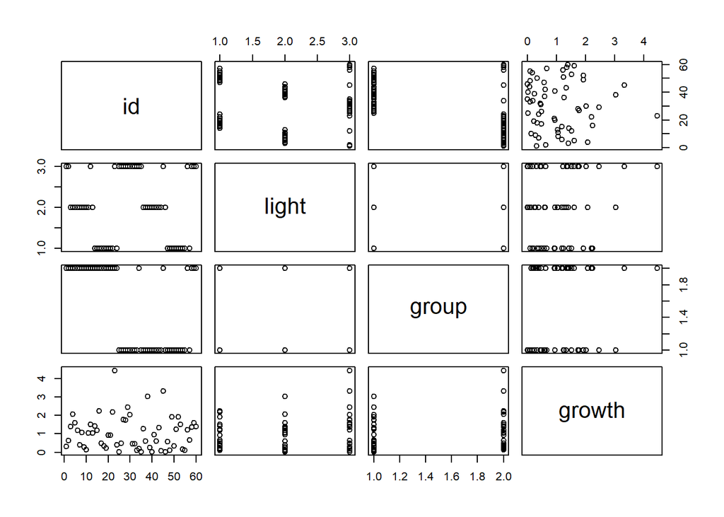

```r
plot(dat)
```

2. Plot `growth` according to `group`

**See solution**

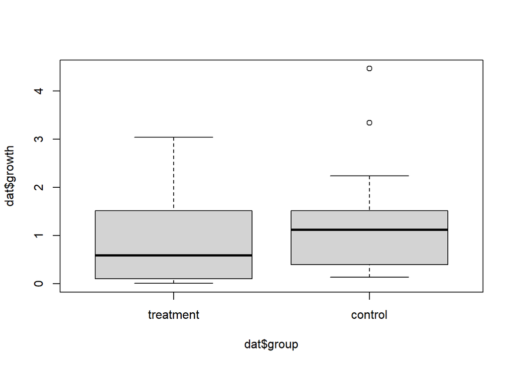

```r
plot(dat$growth ~ dat$group)
```

3. Plot `growth` according to `light`

**See solution**

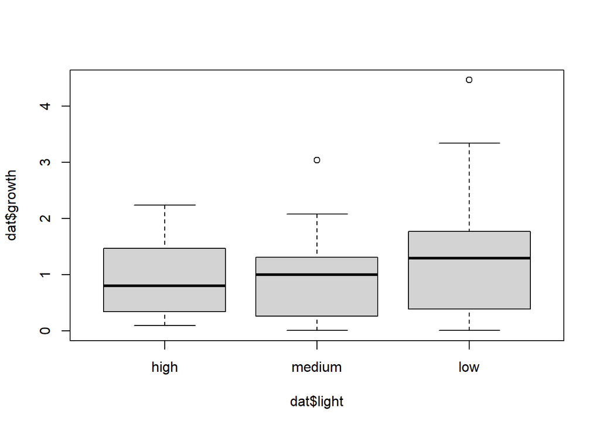

```r
plot(dat$growth ~ dat$light)
```

### 1.4.2 ggplot

1. Violin plot of `growth` according to light (hint: use `geom_violin(trim=F)`:

**See solution**

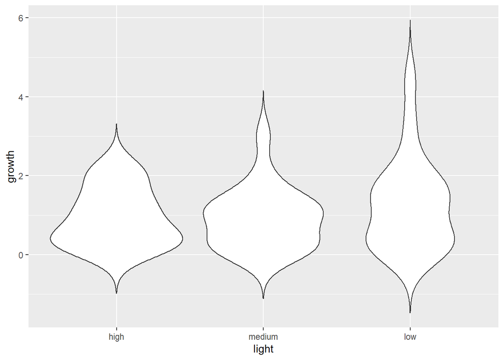

```r
library(ggplot2)
ggplot(dat, aes(x = light, y=growth)) + geom_violin(trim = F)
```

2. Violin plot of `growth` according to `light` and `group`:

**See solution**

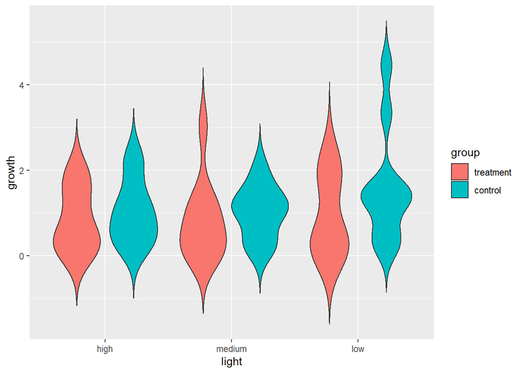

```r
library(ggplot2)

ggplot(dat, aes(x = light, y=growth, fill=group)) + geom_violin(trim = F)
```

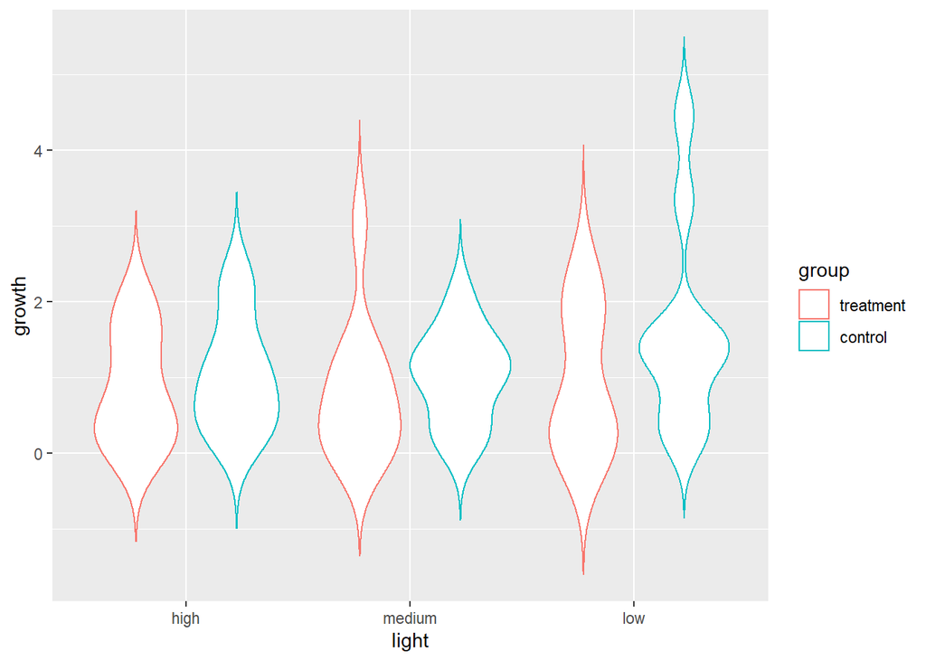

```r
# also

ggplot(dat, aes(x = light, y=growth, color=group)) + geom_violin(trim = F)
```

Go wild with the plot options! Play with them 😃

# 2 Programming

## 2.1 Data manipulation

(hint: use the `quantile()` function)

The solution can be obtained with 2 different codes. Write them both.

**See solution A**

```r
growth_q = quantile(dat$growth)

dat$foo = with(dat,
               ifelse(growth <= growth_q[2], "A",
                      ifelse(growth > growth_q[2] & growth <= growth_q[4],
                             "B",
                             "C")))
```

**See solution B**

```r
growth_q = quantile(dat$growth)

dat$bar = character(nrow(dat))

for (i in 1:nrow(dat)) {
  if (dat[i, "growth"] <= growth_q[2]) {
    dat[i, "bar"] = "A"
  } else if (dat[i, "growth"] > growth_q[2] & dat[i, "growth"] <= growth_q[4]) {
    dat[i, "bar"] = "B"
  } else {
    dat[i, "bar"] = "C"
  }
}
```

2. Create this data set:

```r
data = data.frame(id = paste0("s", 1:100),
                  condition = c(rep(c("A", "B", "C", "D"), each=25)),
                  group = c(rep(c("treatment", "control"), each=50)),
                  sex = c(rep(c("male", "female"), each=50)),
                  rt = rgamma(100, shape=3))
```

Write the code for transforming all the columns identified as `characters` in factors. Two solutions are possible, write them both.

**See solution A**

```r
if (any(sapply(data, is.character)) == TRUE) {
  data[, sapply(data, is.character) == T] = lapply(data[, sapply(data, is.character) == T],
                                                 as.factor)
} else {
  data = data
}
```

**See solution B**

```r
for (i in 1:ncol(data)) {
  if (is.character(data[,i]) == TRUE) {
    data[, i] = as.factor(data[ ,i])
  } else {
    data[ ,i] = data[ ,i]
  }
}
```

## 2.2 Functions

3. Write the function `my_mean()` to compute the mean of a vector without using the `mean()` function (use the `mean()` function just to check whether you did it right)

**See solution**

```r
set.seed(999)
my_mean = function(data) {
  m = sum(data)/length(data)
  return(m)
}

vec = rnorm(10)
my_mean(vec) == mean(vec)
```

```
## [1] TRUE
```

4. Add a check step: If it is not an integer or a numeric vector, throws the error “STOP! I need integer or numeric vectors!”

**See solution**

```r
my_mean = function(data) {
  if (is.integer(data) | is.numeric(data) == FALSE) {
    stop("STOP! I need integer or numeric vectors!")
  } else {
      m = sum(data)/length(data)
  }
    return(m)
}
# Use this cose to check
# vec = letters[1:10]
# my_mean(vec)
#
# my_mean(as.factor(vec))
#
# my_mean(as.logical(vec))
```

5. Define the print method `print.mean()` for `my_mean()` that says “The mean of your vector is:”

**See solution**

```r
print.mean = function(object) {
  cat("The mean of your vector is:", object)
  invisible(object)
}
```

6. `print.mean()` only print objects of class `my.mean`, otherwise it throws the error “Sorry, I print only objects of class my.mean”

**See solution**

```r
my_mean = function(data) {
  if (is.integer(data) | is.numeric(data) == FALSE) {
    stop("STOP! I need integer or numeric vectors!")
  } else {
      m = sum(data)/length(data)
      class(m) = "my.mean"
  }
    return(m)
}

print.mean = function(object) {
  if ((class(object) != "my.mean") == T) {
    stop("Sorry, I print only objects of class my.mean")
  } else {
      cat("The mean of your vector is:", object)
  invisible(object)
  }
}
# Use this code to check
# vec = rnorm(10)
# classic_m = mean(vec)
#
# print.mean(classic_m)
#
# my_m = my_mean(vec)
# print.mean(my_m)
```

**See solution A**

```r
my_factorial = function(number) {
  fact = 1
  for( i in 1:number) {
  fact = fact * i
}
return(fact)
}

my_factorial(5) == factorial(5)
```

```
## [1] TRUE
```

**See solution B**

```r
my_factorial = function(number) {
  fact = number * (number - 1)
  for (i in 2:(number-1)) {
  fact =  fact * (number-i)
  }
  return(fact)
}

my_factorial(5) == factorial(5)
```

```
## [1] TRUE
```

# 3 Shiny

Shiny set up:

```r
install.packages("shiny")
library(shiny)

ui = fluidPage(
  [....]
)

server = function(input, output) {
  [....]
}

shinyApp(ui = ui, server = server)
```

1. Using the template above, create a shiny app with Radio buttons with 4 choices (make them 4 Netflix series). The output is: “You choose X” (where x is the actual input).

**See solution**

```r
ui = fluidPage(
  title = "What is your favorite series?",
  radioButtons("the_choice", "Make your choice!",
               choices = list("Squid game" = "Squid game",
                              "Black mirror" = "Black mirror",
                              "The office" = "The office",
                              "Modern family" = "Modern family")),
  fluidRow(column(4,
                   verbatimTextOutput("choice") ))

)

server = function(input, output) {
  output$choice = renderPrint({
    cat("You choose:", input$the_choice)
  })
}

shinyApp(ui, server)
```

2. Use an action button “Show my choice!” to see the results (Hint: see the examples for `eventReactive()`)

**See solution**

```r
ui = fluidPage(
  title = "What is your favorite series?",
  radioButtons("the_choice", "Make your choice!",
               choices = list("Squid game" = "Squid game",
                              "Black mirror" = "Black mirror",
                              "The office" = "The office",
                              "Modern family" = "Modern family")),

  fluidRow(column(4,
                 actionButton("go", "Show my choice!" ) ),
           column(4,
                   verbatimTextOutput("choice") ))

)

server = function(input, output) {

  choice <- eventReactive(input$go, {
    cat("You choose:", input$the_choice )
  })

  output$choice = renderPrint({
    choice()
  })
}

shinyApp(ui, server)
```

3. Create a 5th option with a text box that appears only if the 5-option (i.e., “Another show”) is selected:

**See solution**

```r
ui = fluidPage(
  title = "What is your favorite series?",
  radioButtons("the_choice", "Make your choice!",
               choices = list("Squid game" = "Squid game",
                              "Black mirror" = "Black mirror",
                              "The office" = "The office",
                              "Modern family" = "Modern family",
                              "Another show" = 5)),
  conditionalPanel(
        condition = "input.the_choice == '5'",
  textInput("my_show", label = "My favorite show", value = "")),

  fluidRow(column(4,
                 actionButton("go", "Show my choice!" ) ),
           column(6,
                   verbatimTextOutput("choice") ))

)

server = function(input, output) {

  choice <- eventReactive(input$go, {
    if (input$the_choice == 5) {
       cat("My favorite show is:", input$my_show )
    } else {
       cat("My favorite show is:", input$the_choice )
    }
  })

  output$choice = renderPrint({
    choice()
  })
}

shinyApp(ui, server)
```

4. Create a shiny app to display the head of the data set chose by the users (stick with radio buttons) (you can use the data sets I used in my slides, but use `mtcars` instead of `cars`). The head can be seen only after an action button is clicked

**See solution**

```r
ui = fluidPage(
        radioButtons(inputId = "dataset",
                    label = "Choose a dataset:",
                    choices = list("rock" = 1,
                                   "pressure" = 2,
                                   "mtcars" = 3)),
        fluidRow(column(4,
                      actionButton("go", "Select dataset")),
                 column(6,
                   tableOutput("summary") ))

           )

server = function(input, output){
    dataInput = eventReactive(input$go, { # here's the action for the button
      if(input$dataset == 1){ # call the input and its options with their label
        data <- rock
      } else if (input$dataset == 2 ){
        data <- pressure
      } else if (input$dataset == 3) {
        data <- mtcars
      }

    }
    )

    output$summary <- renderTable({
      data = dataInput()
      head(data)
    })
}

shinyApp(ui, server)
```

`renderDataTable()` combined with `renderDataTable()` would have been fine as well

5. Use solution 2 for the action button and the data set selection (make sure to write a waiting message) and add a plot (hint: use `sidebarLayout()`). This time use `renderDataTable()`

**See solution**

```r
ui = fluidPage(
   sidebarLayout(
    sidebarPanel(
      selectInput(inputId = "dataset",
                  label = "Choose a dataset:",
                  choices = list("rock" = 1,
                                   "pressure" = 2,
                                   "mtcars" = 3)),

      actionButton("go", "Upload data")
      ),
    mainPanel(
      fluidRow(column(6,
                    plotOutput(
        "graph"
      )  ),
      column(4,
            dataTableOutput(
        "summary"
      ) )
      )

    )
  )
)

server = function(input, output){
 values <- reactiveValues()
  dataInput <- reactive({
    if(input$dataset == 1){
      data <- rock
    } else if (input$dataset == 2 ){
      data <- pressure
    } else if (input$dataset == 3) {
      data <- mtcars
    }
  })
  observeEvent(input$go, { # Use the observeEvent function to make the UI and
    values$data <- data.frame(dataInput()) # server communicate again
  })

  output$graph <- renderPlot({
    plot(values$data[, c(1:2)])
  })

  output$summary <- renderDataTable({
    values$data
  })
}

shinyApp(ui, server)
```

6. Add the code to select two columns to be plotted and displayed:

**See solution**

```r
ui = fluidPage(
   sidebarLayout(
    sidebarPanel(
      selectInput(inputId = "dataset",
                  label = "Choose a dataset:",
                  choices = list("rock" = 1,
                                   "pressure" = 2,
                                   "mtcars" = 3)),

      actionButton("go", "Upload data"),
          conditionalPanel(
        condition = "input.go >= '1'",
        uiOutput("var1"),
        uiOutput("var2"),
        actionButton("select", "Select & Display")
      )
      ),
  mainPanel(
      fluidRow(column(6,
                    plotOutput(
        "graph"
      )  ),
      column(4,
            dataTableOutput(
        "summary"
      ) )
      )

    )
  )
)

server = function(input, output){
 values <- reactiveValues()
  dataInput <- reactive({
    if(input$dataset == 1){
      data <- rock
    } else if (input$dataset == 2 ){
      data <- pressure
    } else if (input$dataset == 3) {
      data <- mtcars
    }
  })
  observeEvent(input$go, {
    values$data <- data.frame(dataInput())
  })

  output$var1 <- renderUI({
    nam <- colnames(values$data)
    selectInput("var1", label = "Select x:",
                choices = c(nam), multiple = FALSE,
                selected = nam[1])
  })

    output$var2 <- renderUI({
    nam <- colnames(values$data)
    selectInput("var2", label = "Select y:",
                choices = c(nam), multiple = FALSE,
                selected = nam[2])
  })
  newdata <- observeEvent(input$select,
                          {
                            values$newdata <- values$data[c(input$var1, input$var2)]
                          })

  output$graph <- renderPlot({
    plot(values$newdata)
  })

  output$summary <- renderDataTable({
    values$newdata
  })
}

shinyApp(ui, server)
```